[figure not shown]

# Bike-Sharing Systems (San Fransico Bay Area vs Chicago) - 2021

## by Folasade Adeyanju

## Investigation Overview

In the Presentation, I focused on comparing the two datasets based on a few variables. This is to establish the similarities and differences between bike trips in the Divvy Biskeshare system of Chicago and Baywheels Bikeshare system of San Francisco Bay Area. There are a total of over 6 million bike trip records for both bike share systems with several variables to compare and establish relationships.

## Dataset Overview

Both Datasets contain about 6.3 million records of bike trips taken in Chicago and the San Fransisco Bay Area. The attributes include the start and end times, start and end latitudes and longitude, subscriber type, month, duration and distance of bike trips. Bike trips less than 60 seconds were removed because they could be potentially false starts or users trying to re-dock a bike to ensure it was secure.

## Baywheels vs Divvy Bike Share System

Here we can see that the Divvy Bikeshare system has a higher number of trips in 2021 when compared with Baywheels Bikeshare system. This wide variance may be attributed to the population in the respective locations. As at 2020 population census, Chicago was known to be the third most populous city in the United State following New York and Los Angeles. This is a possible factor influencing the high frequency of bike trips in the area.

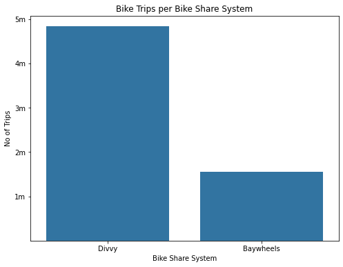

## Distribution of Bike Trip Duration

Bike Duration in seconds in the dataset take on a very large range of values, from about 60seconds at the lowest to about 2.6 million seconds (30 days) at the highest in the Baywheels dataset and 3.3 million seconds (39 days) in the Divvy Bike sharing system for 2021. Plotted on a logarithmic scale, the distribution of bike trip duration takes on a unimodal shape.

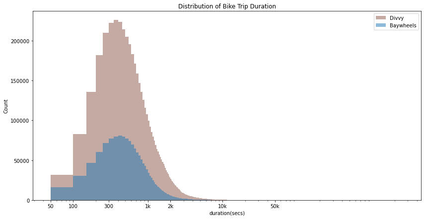

## Distribution of Bike Trip Distance between start and end station

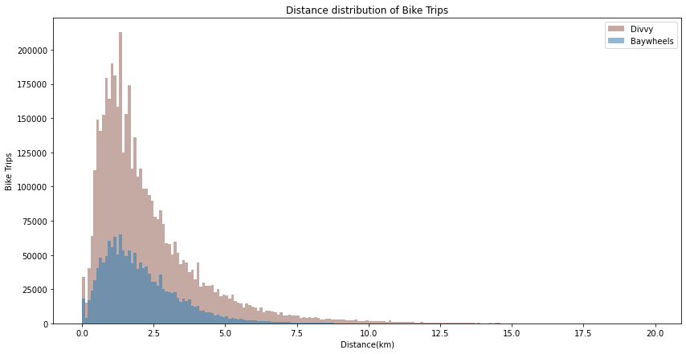

## Bike Trips per Weekday

To show the frequency of bike trips for each weekday in the year, the two datasets were merged to produce one master dataframe. The side by side comparison clearly shows that most bike trips are taken during the weekend in both bike sharing systems - Saturday - Sunday - Friday in that order for Divvy Bike sharing system and Saturday - Friday - Thursday for Baywheels Bike sharing system.

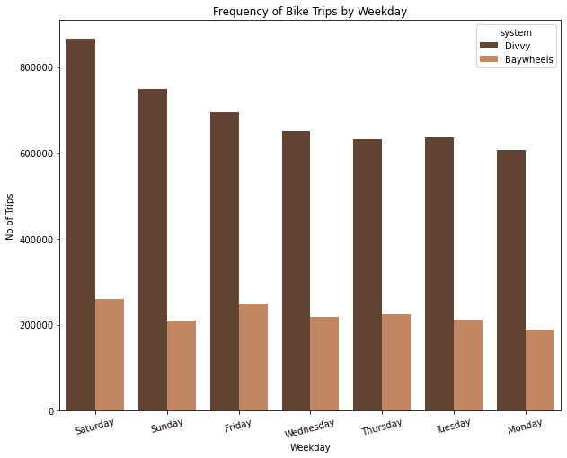

## Bike Trips Per Hour

Using the master dataset created, we can see clearly the similarities in the frequency of bike trips per hour. The most trips are taken at 5pm, 6pm and 4pm respectively in both Divvy and Baywheels Bike sharing systems. The trends continue similarly for the rest of the hours of each day. The high variance in bike trips we see reflects the difference in the number of bike trips between the two bike sharing systems we had earlier established.

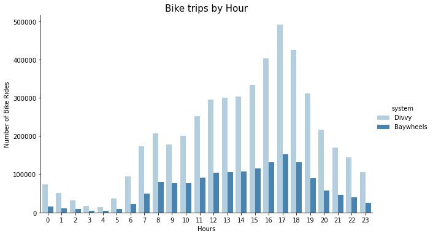

## Comparison of Bike Types

When comparing the bike type used for most trips in Divvy bikeshare system, we can see that the classic bike is the most frequently used followed by the electric bikes. However the most bike type used for the Baywheels bikeshare system is the electric bike. This characteristic difference in both systems suggests that the most preferred bike type differs may depend on the location.

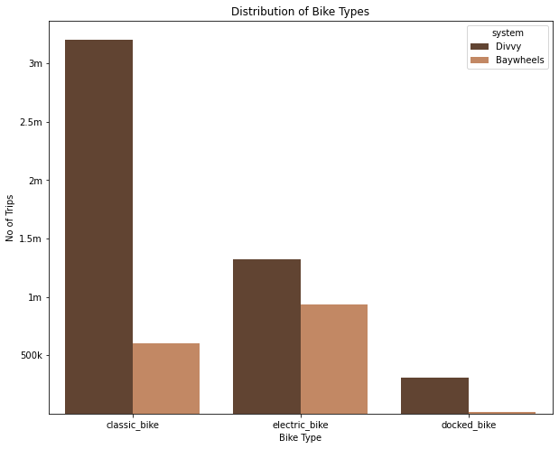

## Relationship between Distance & Duration

There is a weak relationship observed between the Distance and Duration of bike trips in both bike sharing systems. The correlation in both cases is about 0.4. The increase in the distance does not necesarily mean an increase in the duration of bike trips. Here we use a sample of the datasets; this is because we have a large data.

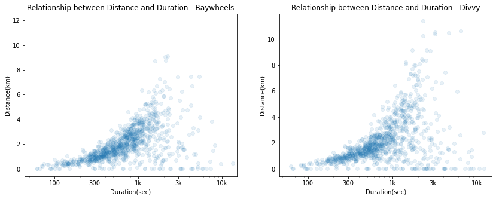

## THANK YOU

[figure not shown]